# Part II - (Prosper Loan Data Exploration)

## by (Aderinsola Joseph)

## Investigation Overview

The main goal of this investigation was to determine the demographics of the borrowers, including their employment status, income range distribution and loan term listings.

## Dataset Overview

The dataset being used for this project is the Prosper loan Dataset, provided by Udacity. There are 113,937 loans in the dataset with 81 features.

### Employment status distribution of borrowers

The distribution of the borrower's job status reveals that the majority of them classify as employed, thus this will serve as our first visualisation to help us learn more about the borrowers.

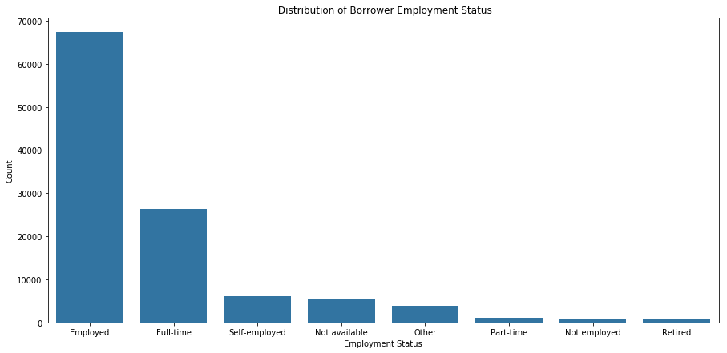

## Income Range Distribution

The breakdown of income ranges reveals that the majority of the borrowers earn between 25,000 and $74,999.

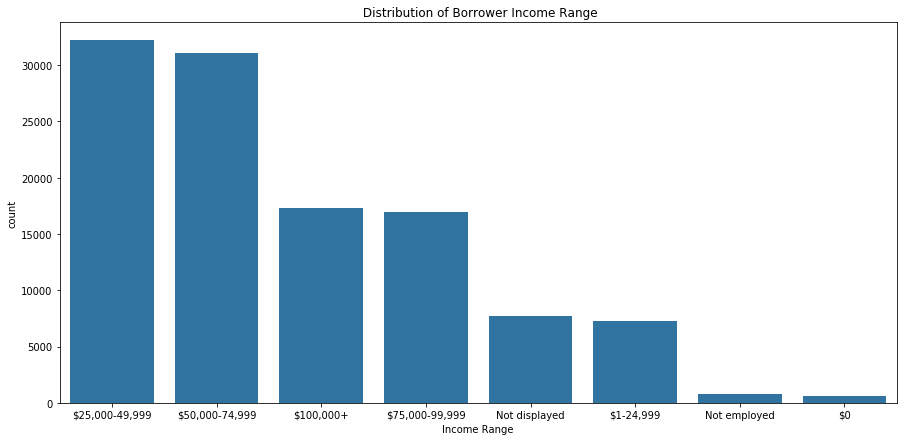

## Loan listings among the loan terms that are offered

The most typical loan length (3 years) was 36 months, and the least typical was 12 months (1 year). Some loans have a period of 60 months (5 years)

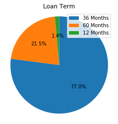

### Submission

If you are using classroom workspace, you can choose from the following two ways of submission:

1. **Submit from the workspace**. Make sure you have removed the example project from the /home/workspace directory. You must submit the following files:
   - Part_I_notebook.ipynb
   - Part_I_notebook.html or pdf
   - Part_II_notebook.ipynb
   - Part_I_slides.html
   - README.md
   - dataset (optional)
1. **Submit a zip file on the last page of this project lesson**. In this case, open the Jupyter terminal and run the command below to generate a ZIP file.

   ```
   zip -r my_project.zip .
   ```

   The command abobve will ZIP every file present in your /home/workspace directory. Next, you can download the zip to your local, and follow the instructions on the last page of this project lesson.